# Advertising

```r
boxplot.stats(numeric_cols$Area.Income)$out
```

```
## [1] 17709.98 18819.34 15598.29 15879.10 14548.06 13996.50 14775.50 18368.57
```

Dropping the outliers

```r
# removing the outliers
#

advert_data1 <- advert_data %>% filter(advert_data$Area.Income >= 20000)
print(dim(advert_data1))
```

```
## [1] 990  10
```

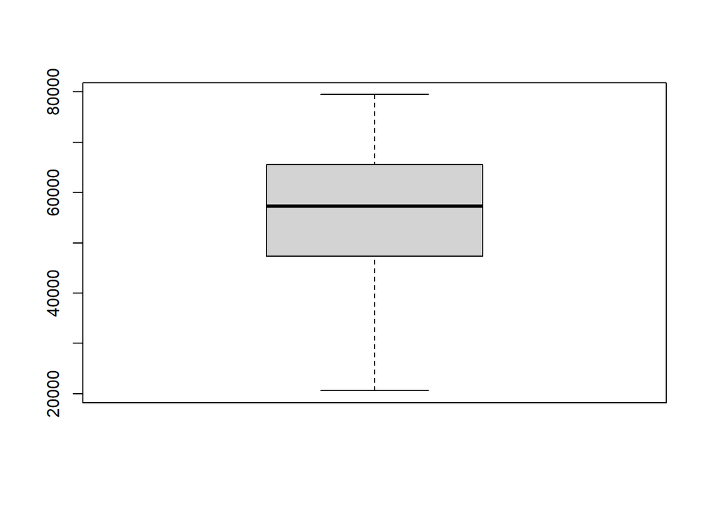

```r
boxplot(advert_data1$Area.Income)
```

```r
# Checking for missing data
#
colSums(is.na(advert_data1))
```

```
## Daily.Time.Spent.on.Site                      Age              Area.Income
##                        0                        0                        0
##     Daily.Internet.Usage            Ad.Topic.Line                     City
##                        0                        0                        0
##                     Male                  Country                Timestamp
##                        0                        0                        0
##            Clicked.on.Ad
##                        0
```

There are no missing values in the dataset

```r
# Checking for duplicates
#
duplicates <- advert_data1[duplicated(advert_data1), ]
duplicates
```

```
##  [1] Daily.Time.Spent.on.Site Age                      Area.Income
##  [4] Daily.Internet.Usage     Ad.Topic.Line            City
##  [7] Male                     Country                  Timestamp
## [10] Clicked.on.Ad
## <0 rows> (or 0-length row.names)
```

There are no duplicates in the dataset.

## Exploratory Analysis

### Univariate Analysis

```r
# checking the top of the dataset
#
head(advert_data1)
```

```
##   Daily.Time.Spent.on.Site Age Area.Income Daily.Internet.Usage
## 1                    68.95  35    61833.90               256.09
## 2                    80.23  31    68441.85               193.77
## 3                    69.47  26    59785.94               236.50
## 4                    74.15  29    54806.18               245.89
## 5                    68.37  35    73889.99               225.58
## 6                    59.99  23    59761.56               226.74
##                           Ad.Topic.Line           City Male    Country
## 1    Cloned 5thgeneration orchestration    Wrightburgh    0    Tunisia
## 2    Monitored national standardization      West Jodi    1      Nauru
## 3      Organic bottom-line service-desk       Davidton    0 San Marino
## 4 Triple-buffered reciprocal time-frame West Terrifurt    1      Italy
## 5         Robust logistical utilization   South Manuel    0    Iceland
## 6       Sharable client-driven software      Jamieberg    1     Norway
##             Timestamp Clicked.on.Ad
## 1 2016-03-27 00:53:11             0
## 2 2016-04-04 01:39:02             0
## 3 2016-03-13 20:35:42             0
## 4 2016-01-10 02:31:19             0
## 5 2016-06-03 03:36:18             0
## 6 2016-05-19 14:30:17             0
```

```r
# Checking for the mean age
#
mean_age <- mean(advert_data1$Age)
mean_age
```

```
## [1] 35.98384
```

The mean age of the individuals is 35.9834

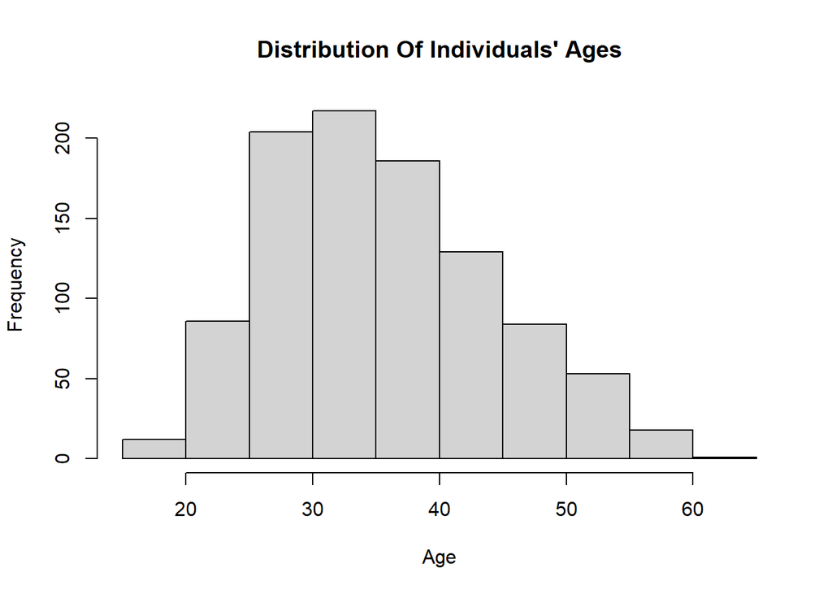

```r
# Checking on the distribution of age
#
hist(advert_data1$Age, main="Distribution Of Individuals' Ages", xlab = "Age" )
```

The most individuals whose data was taken are between 25-40 years.

```r
# checking the average time people spend on the site
#
mean_time <- mean(advert_data1$Daily.Time.Spent.on.Site)
mean_time
```

```
## [1] 65.05808
```

The average time spent on that site is 65.05808 minutes

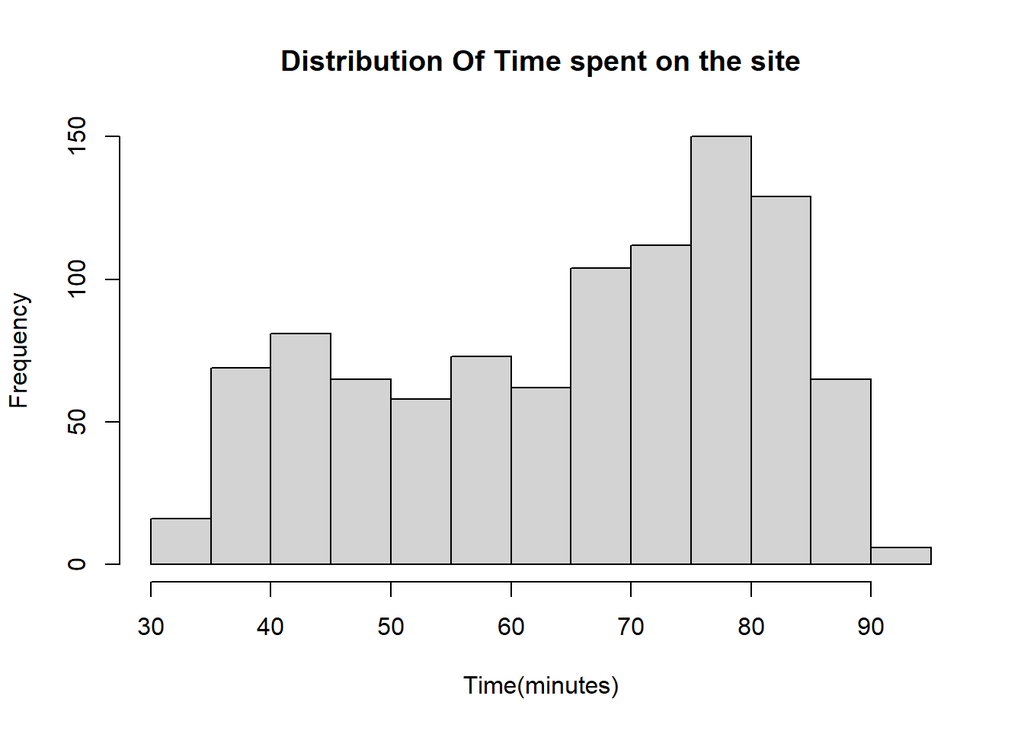

```r
# Checking on the distribution of time spent in the site
#
hist(advert_data1$Daily.Time.Spent.on.Site, main="Distribution Of Time spent on the site", xlab = "Time(minutes)" )
```

Most people stayed on the blog for 65-85 minutes.

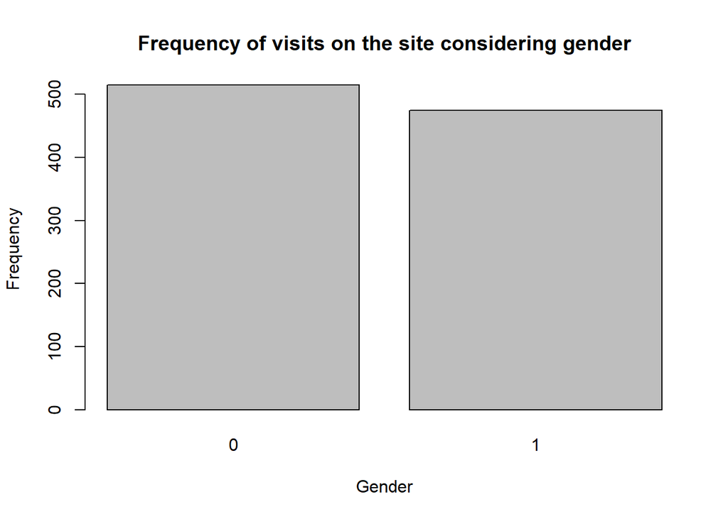

```r
# checking for the distribution of gender.
#
gender <- table(advert_data1$Male)
barplot(gender, main = "Frequency of visits on the site considering gender", xlab = "Gender", ylab = "Frequency", decreasing = TRUE)
```

Most of the individuals who visited the blog/site were female.

```r
# Checking the average income of the individuals
#
mean_income <- mean(advert_data1$Area.Income)
mean_income
```

```
## [1] 55384.82
```

The mean income of the individuals was ksh 55384.82

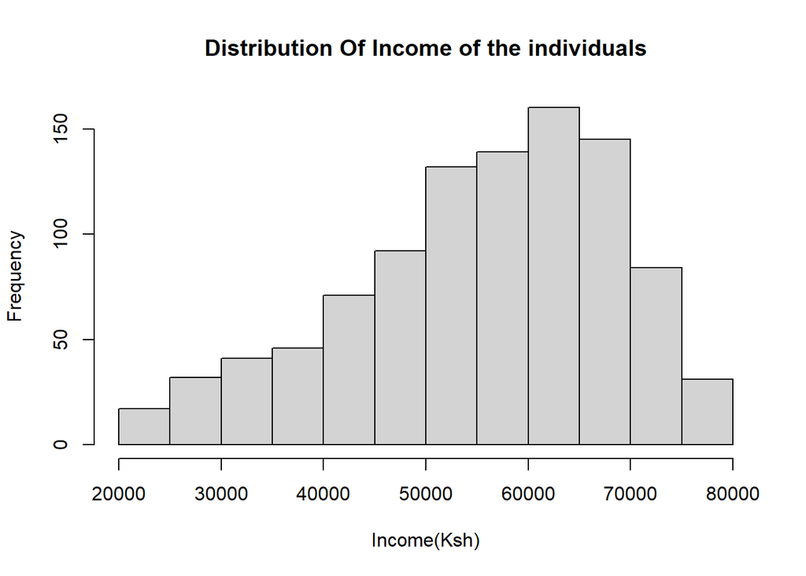

```r
# Checking the distribution of income
#
hist(advert_data1$Area.Income, main="Distribution Of Income of the individuals", xlab = "Income(Ksh)")
```

Most of the individuals are earning between ksh 50000-70000

```r
# Checking on the average daily internet usage
#
mean_internet_usage <- mean(advert_data1$Daily.Internet.Usage)
mean_internet_usage
```

```
## [1] 180.0282
```

The average daily internet usage is 180.0282 Mbs.

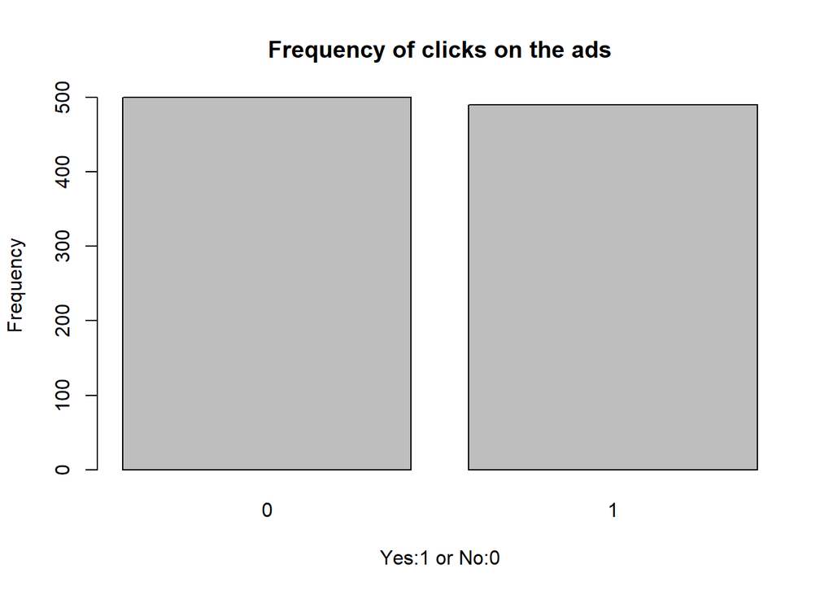

```r
# Checking on the individuals who clicked on the ads
#
ads_click <- table(advert_data1$Clicked.on.Ad)
barplot(ads_click, main = "Frequency of clicks on the ads", xlab = "Yes:1 or No:0", ylab = "Frequency", decreasing = TRUE)
```

Its almost a fair share of the individuals who clicked on the ads but those who did not were slightly more than those who did.

#### Univariate Analysis Summary.

1. The mean age of the individuals was say 36 years(35.9834 in fact).More to that, the age cluster of most individuals whose data was taken was between 25-40 years.
2. The average time spent on that site is 65.05808 minutes and Most people stayed on the blog for around 65-85 minutes.
3. Most of the individuals who visited the blog/site were female.
4. The mean income of the individuals was ksh 55384.82. Moreover, most of the individuals are earning between ksh 50000-70000.
5. The average daily internet usage is 180.0282 Mbs.
6. Lastly, its almost a fair share of the individuals who clicked on the ads but those who did not were slightly more than those who did.

### Bivariate Analysis

```r
head(advert_data1)
```

```
##   Daily.Time.Spent.on.Site Age Area.Income Daily.Internet.Usage
## 1                    68.95  35    61833.90               256.09
## 2                    80.23  31    68441.85               193.77
## 3                    69.47  26    59785.94               236.50
## 4                    74.15  29    54806.18               245.89
## 5                    68.37  35    73889.99               225.58
## 6                    59.99  23    59761.56               226.74
##                           Ad.Topic.Line           City Male    Country
## 1    Cloned 5thgeneration orchestration    Wrightburgh    0    Tunisia
## 2    Monitored national standardization      West Jodi    1      Nauru
## 3      Organic bottom-line service-desk       Davidton    0 San Marino
## 4 Triple-buffered reciprocal time-frame West Terrifurt    1      Italy
## 5         Robust logistical utilization   South Manuel    0    Iceland
## 6       Sharable client-driven software      Jamieberg    1     Norway
##             Timestamp Clicked.on.Ad
## 1 2016-03-27 00:53:11             0
## 2 2016-04-04 01:39:02             0
## 3 2016-03-13 20:35:42             0
## 4 2016-01-10 02:31:19             0
## 5 2016-06-03 03:36:18             0
## 6 2016-05-19 14:30:17             0
```

```r
# Checking for relationship of age and income
#
ages <- advert_data1$Age
income <- advert_data1$Area.Income

cor(ages,income)
```

```
## [1] -0.181831
```

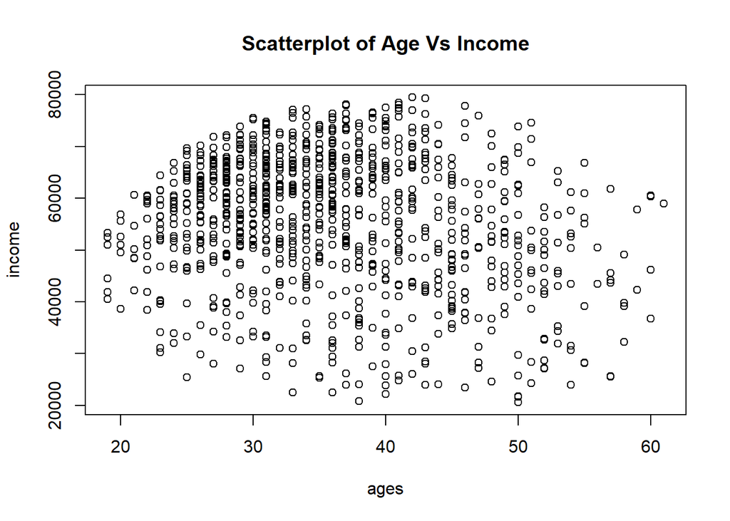

```r
plot(ages,income,main = "Scatterplot of Age Vs Income")
```

The correlation coefficient of income and age is -0.181831. Thus there is a very weak negative relationship between the two variables.

```r
# Checking for relationship of daily internet usage and income
#
internet_usage <- advert_data1$Daily.Internet.Usage
income <- advert_data1$Area.Income

cor(internet_usage,income)
```

```
## [1] 0.3510049
```

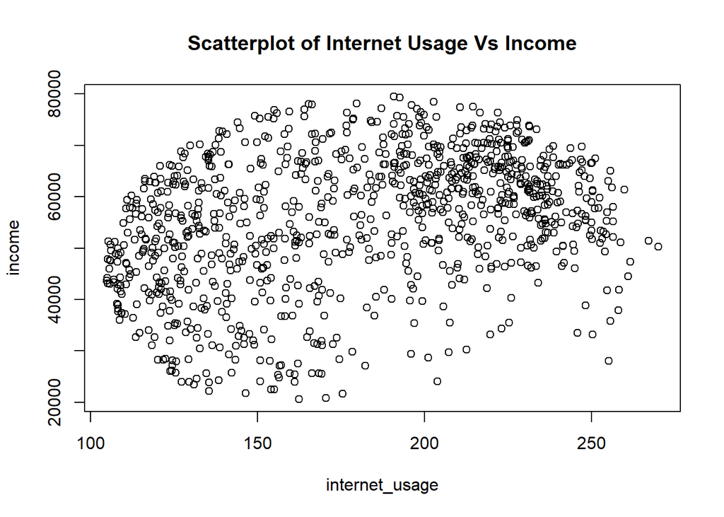

```r
plot(internet_usage,income,main = "Scatterplot of Internet Usage Vs Income")
```

The correlation coefficient of income and internet usage is 0.3510049. Thus there is a weak positive relationship between the two variables.

```r
# Checking on the individuals who clicked on the ads based on gender
#
gender01 <- advert_data1$Male
clicks01 <- advert_data1$Clicked.on.Ad
# Male <- advert_data %>% filter(advert_data$Male == 1)
# Female <- advert_data %>% filter(advert_data$Male == 0)
# clicked <- advert_data %>% filter(advert_data$Clicked.on.Ad == 1)
# not_clicked <- advert_data %>% filter(advert_data$Clicked.on.Ad == 0)

cor(clicks01,income)
```

```
## [1] -0.4694387
```

```r
cor(gender01,clicks01)
```

```
## [1] -0.0408476
```

The correlation coefficient of income and clicks on the ads is -0.4694387. Thus there is a weak negative relationship between the two variables. The correlation coefficient of gender and clicks on the ads is -0.0408476. Thus there is a very weak negative relationship between the two variables